# Continuous Control

You are welcome to use this coding environment to train your agent for the project. Follow the instructions below to get started!

### 1. Start the Environment

Run the next code cell to install a few packages. This line will take a few minutes to run!

```python
!pip -q install ./python
```

```
tensorflow 1.7.1 has requirement numpy>=1.13.3, but you'll have numpy 1.12.1 which is incompatible.
ipython 6.5.0 has requirement prompt-toolkit<2.0.0,>=1.0.15, but you'll have prompt-toolkit 2.0.10 which is incompatible.
```

The environments corresponding to both versions of the environment are already saved in the Workspace and can be accessed at the file paths provided below.

Please select one of the two options below for loading the environment.

```python
from unityagents import UnityEnvironment
import numpy as np

# select this option to load version 1 (with a single agent) of the environment
env = UnityEnvironment(file_name='/data/Reacher_One_Linux_NoVis/Reacher_One_Linux_NoVis.x86_64')

# select this option to load version 2 (with 20 agents) of the environment
# env = UnityEnvironment(file_name='/data/Reacher_Linux_NoVis/Reacher.x86_64')
```

```
INFO:unityagents:
'Academy' started successfully!
Unity Academy name: Academy
        Number of Brains: 1
        Number of External Brains : 1
        Lesson number : 0
        Reset Parameters :
		goal_speed -> 1.0
		goal_size -> 5.0
Unity brain name: ReacherBrain
        Number of Visual Observations (per agent): 0
        Vector Observation space type: continuous
        Vector Observation space size (per agent): 33
        Number of stacked Vector Observation: 1
        Vector Action space type: continuous
        Vector Action space size (per agent): 4
        Vector Action descriptions: , , ,
```

Environments contain *brains* which are responsible for deciding the actions of their associated agents. Here we check for the first brain available, and set it as the default brain we will be controlling from Python.

```python
# get the default brain
brain_name = env.brain_names[0]
brain = env.brains[brain_name]
```

### 2. Examine the State and Action Spaces

Run the code cell below to print some information about the environment.

```python
# reset the environment
env_info = env.reset(train_mode=True)[brain_name]

# number of agents
num_agents = len(env_info.agents)
print('Number of agents:', num_agents)

# size of each action
action_size = brain.vector_action_space_size
print('Size of each action:', action_size)

# examine the state space
states = env_info.vector_observations
state_size = states.shape[1]
print('There are {} agents. Each observes a state with length: {}'.format(states.shape[0], state_size))
# print('The state for the first agent looks like:', states[0])
```

```
Number of agents: 1
Size of each action: 4
There are 1 agents. Each observes a state with length: 33
```

### 3. Take Random Actions in the Environment

In the next code cell, you will learn how to use the Python API to control the agent and receive feedback from the environment.

Note that **in this coding environment, you will not be able to watch the agents while they are training**, and you should set `train_mode=True` to restart the environment.

```python
env_info = env.reset(train_mode=True)[brain_name]      # reset the environment
states = env_info.vector_observations                  # get the current state (for each agent)
scores = np.zeros(num_agents)                          # initialize the score (for each agent)
while True:
    actions = np.random.randn(num_agents, action_size) # select an action (for each agent)
    actions = np.clip(actions, -1, 1)                  # all actions between -1 and 1
    env_info = env.step(actions)[brain_name]           # send all actions to tne environment
    next_states = env_info.vector_observations         # get next state (for each agent)
    rewards = env_info.rewards                         # get reward (for each agent)
    dones = env_info.local_done                        # see if episode finished
    scores += env_info.rewards                         # update the score (for each agent)
    states = next_states                               # roll over states to next time step
    if np.any(dones):                                  # exit loop if episode finished
        break
print('Total score (averaged over agents) this episode: {}'.format(np.mean(scores)))
```

```
Total score (averaged over agents) this episode: 0.6199999861419201
```

When finished, you can close the environment.

```python
# env.close()
```

### 4. It's Your Turn!

Now it's your turn to train your own agent to solve the environment! A few **important notes**:

- When training the environment, set `train_mode=True`, so that the line for resetting the environment looks like the following:

  ```
  env_info = env.reset(train_mode=True)[brain_name]
  ```

- To structure your work, you're welcome to work directly in this Jupyter notebook, or you might like to start over with a new file! You can see the list of files in the workspace by clicking on *Jupyter* in the top left corner of the notebook.
- In this coding environment, you will not be able to watch the agents while they are training. However, *after training the agents*, you can download the saved model weights to watch the agents on your own machine!

```python
import matplotlib.pyplot as plt
%matplotlib inline

import numpy as np
import random
import time
import torch

from collections import deque
from ddpg_agent import Agent
from unityagents import UnityEnvironment
```

```python
seed = 0
```

```python
# DDPG function

def ddpg(n_episodes=2500, max_t=1000, print_every=10):
    """Deep Deterministic Policy Gradient (DDPG)

    Params
    ======
        n_episodes  (int)   : maximum number of training episodes
        max_t       (int)   : maximum number of timesteps per episode
        print_every (int)   : interval to display results

    """
    m_scores = []                               # list of mean scores from each episode
    scores_deque = deque(maxlen=100)            # mean scores from most recent 100 episodes
    avg_score = []

    for i_episode in range(1, n_episodes+1):
        env_info = env.reset(train_mode=True)[brain_name]       # reset environment
        states = env_info.vector_observations                   # get current state for each agent
        scores = np.zeros(num_agents)                           # initialize score for each agent
        agent.reset()
        for t in range(max_t):
            actions = agent.act(states, add_noise=True)         # select an action
            env_info = env.step(actions)[brain_name]            # send actions to environment
            next_states = env_info.vector_observations          # get next state
            rewards = env_info.rewards                          # get reward
            dones = env_info.local_done                         # see if episode has finished
            # save experience to replay buffer, perform learning step at defined interval
            for state, action, reward, next_state, done in zip(states, actions, rewards, next_states, dones):
                agent.step(state, action, reward, next_state, done, t)
            states = next_states
            scores += rewards
            if np.any(dones):                                   # exit loop when episode ends
                break
        m_scores.append(np.mean(scores))           # save mean score for the episode
        scores_deque.append(m_scores[-1])         # save mean score to window
        avg_score.append(np.mean(scores_deque))

        if i_episode % print_every == 0:
            print('\rEpisode {}\tScore: {:.2f}\tAverage Score: {:.2f}'.format(i_episode, m_scores[-1], avg_score[-1]))

        if avg_score[-1] >= 30.00:
            print('\nEnvironment solved in {:d} episodes!\tAverage Score: {:.2f}'.format(i_episode-100, avg_score[-1]))
            break

    return m_scores, avg_score
```

```python
# run the training loop
agent = Agent(state_size=state_size, action_size=action_size, random_seed=seed)
scores, avgs = ddpg()
```

```
Episode 10	Score: 0.24	Average Score: 0.30
Episode 20	Score: 0.64	Average Score: 0.53
Episode 30	Score: 3.23	Average Score: 0.66
Episode 40	Score: 1.54	Average Score: 0.88
Episode 50	Score: 1.48	Average Score: 1.19
Episode 60	Score: 1.38	Average Score: 1.34
Episode 70	Score: 4.86	Average Score: 1.46
Episode 80	Score: 3.26	Average Score: 1.60
Episode 90	Score: 5.44	Average Score: 1.73
Episode 100	Score: 3.89	Average Score: 1.86
Episode 110	Score: 2.17	Average Score: 2.04
Episode 120	Score: 1.36	Average Score: 2.24
Episode 130	Score: 3.40	Average Score: 2.51
Episode 140	Score: 5.40	Average Score: 2.76
Episode 150	Score: 5.31	Average Score: 2.98
Episode 160	Score: 5.49	Average Score: 3.29
Episode 170	Score: 4.82	Average Score: 3.56
Episode 180	Score: 4.47	Average Score: 3.78
Episode 190	Score: 7.98	Average Score: 4.12
Episode 200	Score: 5.87	Average Score: 4.41
Episode 210	Score: 7.31	Average Score: 4.78
Episode 220	Score: 6.94	Average Score: 5.30
Episode 230	Score: 4.35	Average Score: 5.50
Episode 240	Score: 4.78	Average Score: 5.68
Episode 250	Score: 8.36	Average Score: 5.97
Episode 260	Score: 11.91	Average Score: 6.15
Episode 270	Score: 4.87	Average Score: 6.31
Episode 280	Score: 10.82	Average Score: 6.69
Episode 290	Score: 6.23	Average Score: 6.85
Episode 300	Score: 7.02	Average Score: 7.02
Episode 310	Score: 7.44	Average Score: 7.36
Episode 320	Score: 14.41	Average Score: 7.48
Episode 330	Score: 8.58	Average Score: 7.85
Episode 340	Score: 13.32	Average Score: 8.14
Episode 350	Score: 8.83	Average Score: 8.15
Episode 360	Score: 7.19	Average Score: 8.33
Episode 370	Score: 8.74	Average Score: 8.56
Episode 380	Score: 11.00	Average Score: 8.64
Episode 390	Score: 11.19	Average Score: 8.85
Episode 400	Score: 8.80	Average Score: 9.20
```

[output cut: 28 more lines]

```
Episode 690	Score: 29.70	Average Score: 22.57
Episode 700	Score: 28.04	Average Score: 23.10
Episode 710	Score: 24.18	Average Score: 23.87
Episode 720	Score: 30.65	Average Score: 24.56
Episode 730	Score: 32.59	Average Score: 25.07
Episode 740	Score: 26.14	Average Score: 25.66
Episode 750	Score: 28.14	Average Score: 26.50
Episode 760	Score: 35.03	Average Score: 27.13
Episode 770	Score: 37.64	Average Score: 27.81
Episode 780	Score: 28.70	Average Score: 28.19
Episode 790	Score: 29.00	Average Score: 28.76
Episode 800	Score: 33.79	Average Score: 29.47
Episode 810	Score: 27.95	Average Score: 29.95

Environment solved in 713 episodes!	Average Score: 30.07
```

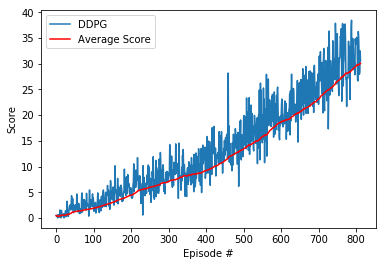

```python
# plot the scores
fig = plt.figure()
ax = fig.add_subplot(111)
plt.plot(np.arange(len(scores)), scores, label='DDPG')
plt.plot(np.arange(len(scores)), avgs, c='r', label='Average Score')
plt.ylabel('Score')
plt.xlabel('Episode #')
plt.legend(loc='upper left');
plt.show()
```

```python
env.close()
```